# Calc_II_Oil_Spill

## The Deepwater Horizon Oil Spill

In the spring of 2010, the Deepwater Horizon, an oil rig in the Gulf of Mexico, exploded and sank causing one of the largest oil spills in history. The rig was situated over an oil well that was about fifteen-hundred meters below sea level. On April 20th, a swell of natural gas rushed through a recently installed concrete core that was installed to seal the well. The natural gas traveled up to the rig’s platform where it killed almost a dozen workers and injured several more. On April 22nd,the rig sank which broke the machine that was responsible for balancing out the upward force of the gas and oil. Without its opposing force, oil began seeping into the gulf. The U.S. government estimated that approximately sixty-thousand barrels of oil were discharged per day. The following analysis will examine the data and total oil that affected the Gulf.

**Table 1:** Cumulative oil (in barrels) that entered the Gulf based on flow-rate estimates, adjusting for oil recovered by BP.

| Day | Total Oil |
| --- | --- |
| 1 | 5000 |
| 2 | 67000 |
| 3 | 128888 |
| 4 | 190663 |
| 5 | 252325 |
| 6 | 313875 |
| 7 | 375313 |
| 8 | 436638 |
| 9 | 497850 |
| 10 | 558950 |
| 11 | 619938 |
| 12 | 680813 |
| 13 | 741575 |
| 14 | 802225 |
| 15 | 862763 |
| 16 | 923188 |
| 17 | 983500 |
| 18 | 1043700 |
| 19 | 1103788 |
| 20 | 1163763 |
| 21 | 1223625 |
| 22 | 1283375 |

| Day | Total Oil |
| --- | --- |
| 23 | 1343013 |
| 24 | 1402538 |
| 25 | 1461950 |
| 26 | 1521250 |
| 27 | 1580438 |
| 28 | 1639513 |
| 29 | 1698475 |
| 30 | 1757325 |
| 31 | 1816063 |
| 32 | 1874688 |
| 33 | 1933200 |
| 34 | 1991600 |
| 35 | 2049888 |
| 36 | 2108063 |
| 37 | 2166125 |
| 38 | 2224075 |
| 39 | 2281913 |
| 40 | 2339638 |
| 41 | 2397250 |
| 42 | 2454750 |
| 43 | 2514372 |
| 44 | 2567787 |

| Day | Total Oil |
| --- | --- |
| 45 | 2616605 |
| 46 | 2664639 |
| 47 | 2708787 |
| 48 | 2752609 |
| 49 | 2795460 |
| 50 | 2838563 |
| 51 | 2881351 |
| 52 | 2924493 |
| 53 | 2967304 |
| 54 | 3009741 |
| 55 | 3056988 |
| 56 | 3096295 |
| 57 | 3128371 |
| 58 | 3161029 |
| 59 | 3197035 |
| 60 | 3230630 |
| 61 | 3261537 |
| 62 | 3291002 |
| 63 | 3330535 |
| 64 | 3363039 |
| 65 | 3394567 |
| 66 | 3427724 |

| Day | Total Oil |
| --- | --- |
| 67 | 3459022 |
| 68 | 3491212 |
| 69 | 3521418 |
| 70 | 3553606 |
| 71 | 3583557 |
| 72 | 3613208 |
| 73 | 3642791 |
| 74 | 3672451 |
| 75 | 3701926 |
| 76 | 3731460 |
| 77 | 3761015 |
| 78 | 3790587 |
| 79 | 3819604 |
| 80 | 3858052 |
| 81 | 3903303 |
| 82 | 3948324 |
| 83 | 3984423 |
| 84 | 4024581 |
| 85 | 4068111 |

```
Figure 1: Cumulative oil (in barrels) that entered the Gulf based on flowrate estimates, adjusting for oil recovered by BP.
```

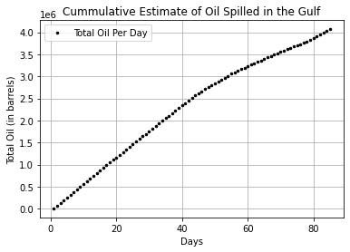

```python
import pandas as pd
import numpy as np
import matplotlib.pyplot as plt
import math

#Reads in data from html table above
df = pd.read_html("<table><tr><th>Days</th><th>Total Oil</th></tr><tr><td>1</td><td>5000</td></tr><tr><td>2</td><td>67000</td></tr> <tr> <td>3</td> <td>128888</td> </tr> <tr> <td>4</td> <td>190663</td> </tr> <tr> <td>5</td> <td>252325</td></tr><tr><td>6</td> <td>313875</td> </tr> <tr> <td>7</td> <td>375313</td> </tr> <tr> <td>8</td> <td>436638</td> </tr> <tr> <td>9</td> <td>497850</td> </tr><tr> <td>10</td> <td>558950</td> </tr> <tr> <td>11</td> <td>619938</td> </tr> <tr> <td>12</td> <td>680813</td> </tr> <tr> <td>13</td> <td>741575</td></tr> <tr> <td>14</td> <td>802225</td> </tr> <tr> <td>15</td> <td>862763</td> </tr> <tr> <td>16</td> <td>923188</td> </tr> <tr> <td>17</td><td>983500</td> </tr> <tr> <td>18</td> <td>1043700</td> </tr> <tr> <td>19</td> <td>1103788</td> </tr> <tr> <td>20</td> <td>1163763</td></tr> <tr> <td>21</td> <td>1223625</td> </tr> <tr> <td>22</td> <td>1283375</td> </tr><tr><td>23</td> <td>1343013</td> </tr> <tr> <td>24</td> <td>1402538</td> </tr> <tr> <td>25</td> <td>1461950</td> </tr> <tr> <td>26</td> <td>1521250</td> </tr> <tr> <td>27</td> <td>1580438</td> </tr> <tr> <td>28</td> <td>1639513</td> </tr> <tr> <td>29</td> <td>1698475</td> </tr> <tr> <td>30</td> <td>1757325</td> </tr> <tr> <td>31</td> <td>1816063</td> </tr> <tr> <td>32</td> <td>1874688</td> </tr> <tr> <td>33</td> <td>1933200</td> </tr><tr> <td>34</td> <td>1991600</td> </tr><tr> <td>35</td> <td>2049888</td> </tr> <tr> <td>36</td> <td>2108063</td></tr> <tr> <td>37</td> <td>2166125</td> </tr> <tr> <td>38</td> <td>2224075</td> </tr> <tr> <td>39</td> <td>2281913</td> </tr> <tr> <td>40</td> <td>2339638</td> </tr> <tr> <td>41</td> <td>2397250</td> </tr> <tr> <td>42</td> <td>2454750</td> </tr> <tr> <td>43</td> <td>2514372</td> </tr> <tr> <td>44</td> <td>2567787</td></tr><tr><td>45</td><td>2616605</td></tr><tr> <td>46</td> <td>2664639</td> </tr> <tr> <td>47</td> <td>2708787</td> </tr> <tr> <td>48</td> <td>2752609</td> </tr> <tr> <td>49</td> <td>2795460</td> </tr> <tr> <td>50</td> <td>2838563</td> </tr> <tr> <td>51</td> <td>2881351</td> </tr> <tr> <td>52</td> <td>2924493</td> </tr> <tr> <td>53</td> <td>2967304</td> </tr> <tr> <td>54</td> <td>3009741</td> </tr> <tr> <td>55</td> <td>3056988</td> </tr> <tr> <td>56</td> <td>3096295</td> </tr> <tr> <td>57</td> <td>3128371</td> </tr> <tr> <td>58</td> <td>3161029</td> </tr> <tr> <td>59</td> <td>3197035</td> </tr> <tr> <td>60</td> <td>3230630</td> </tr> <tr> <td>61</td> <td>3261537</td> </tr> <tr> <td>62</td> <td>3291002</td> </tr> <tr> <td>63</td> <td>3330535</td> </tr> <tr> <td>64</td> <td>3363039</td> </tr> <tr> <td>65</td> <td>3394567</td> </tr> <tr> <td>66</td><td>3427724</td></tr><tr> <td>67</td> <td>3459022</td> </tr> <tr> <td>68</td> <td>3491212</td> </tr> <tr> <td>69</td> <td>3521418</td> </tr> <tr> <td>70</td><td>3553606</td> </tr> <tr> <td>71</td> <td>3583557</td> </tr> <tr> <td>72</td> <td>3613208</td> </tr> <tr> <td>73</td> <td>3642791</td> </tr> <tr> <td>74</td> <td>3672451</td> </tr> <tr> <td>75</td> <td>3701926</td> </tr> <tr> <td>76</td> <td>3731460</td> </tr> <tr> <td>77</td> <td>3761015</td> </tr> <tr> <td>78</td> <td>3790587</td> </tr> <tr> <td>79</td> <td>3819604</td> </tr> <tr> <td>80</td> <td>3858052</td> </tr> <tr> <td>81</td> <td>3903303</td> </tr> <tr> <td>82</td> <td>3948324</td> </tr> <tr> <td>83</td> <td>3984423</td> </tr> <tr> <td>84</td> <td>4024581</td> </tr> <tr> <td>85</td> <td>4068111</td> </tr> </table>")
df1 = df[0]

#Graph of data
plt.plot(df1['Days'],df1['Total Oil'], "k.", markersize =5, label="Total Oil Per Day")
plt.title("Cummulative Estimate of Oil Spilled in the Gulf")
plt.xlabel('Days')
plt.ylabel('Total Oil (in barrels)')
plt.grid()
plt.legend(loc='best')

print('\033[1m' + 'Figure 1: ' + '\033[0m' + 'Cumulative oil (in barrels) that entered the Gulf based on flowrate estimates, adjusting for oil recovered by BP. ')
```

**How reliable do you think your data are and why? Can any real-life data be 100% reliable? What could have led to errors in a particular data set?**

I feel the data is only somewhat reliable especially because they are estimates. While a great amount did spill into the Gulf with an estimate of 60,000 barrels of oil each day, we don't know for sure if that is the true amount that spilled. Especially because it wasn't measured and recorded, that provides an extra margin of error. Even when we do record and study data as accurately as possible, no data can be 100% reliable. There will always be some unknown bias or factor that is unaccounted for. We never know if studies will be 100% as most of the time they are sample studies. Samples can never account for the whole population studied, be it people or barrels of oil spilled. Therefore, all studies are always prone to at least a small margin of error. In our data set, we don't know if the oil leaked from multiple locations under the water or there is leakage that is not accounted for. Again, there can be unknown factors in any data set. When you record data, you can never get a full record of that data either. On day 1, our data says the equivalent of 5000 barrels of oil spilled from the oil rig into the Gulf. Was it exactly 5000.0000... barrels? Most likely no. Our data above and in many studies are approximations, even when using the most advanced technology to measure something. There can always be an extra decimal place that is missed or isn't measured. 5.5 can be a lot different than 5 in a data set. Thus, errors are very common in research, no matter how small, and shows that real life data isn't always 100% reliable.

## Curve Fitting

```
Figure 4.1, 4.2, 4.3:  Curve Fitting of the data from Table 1 using increasing degrees of polynomials.
```

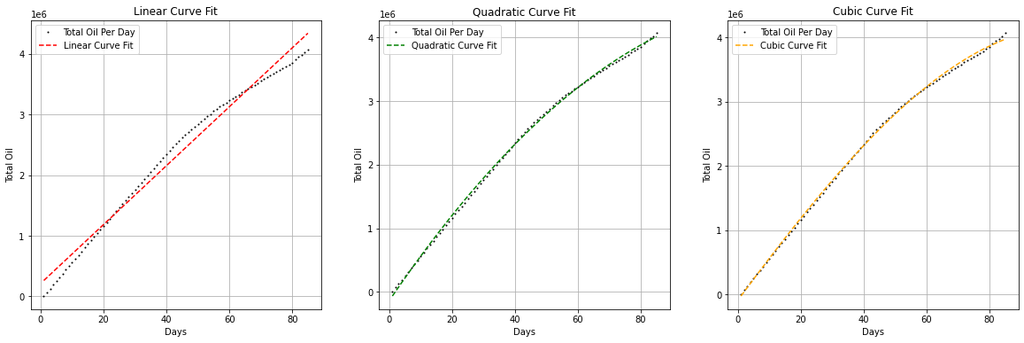

```python
fig, (linear_function,quad_function, cubic_function) = plt.subplots(nrows = 1, ncols = 3, figsize=(20,6))

#Create the functions for each degree of polynomial
x_i = np.linspace(1,85,850)

linearFormula = np.polyfit(df1["Days"],df1["Total Oil"],1)
linY = np.polyval(linearFormula, x_i)

quadFormula = np.polyfit(df1["Days"],df1["Total Oil"],2)
quadY = np.polyval(quadFormula, x_i)

cubicFormula = np.polyfit(df1["Days"],df1["Total Oil"],3)
cubicY = np.polyval(cubicFormula, x_i)

#Linear formula plot
linear_function.plot(df1["Days"],df1["Total Oil"], "k.", markersize=2)
linear_function.plot(x_i, linY, "r--")
linear_function.set_title("Linear Curve Fit")
linear_function.set_xlabel("Days")
linear_function.set_ylabel("Total Oil")
linear_function.grid()
linear_function.legend(["Total Oil Per Day", "Linear Curve Fit"],loc="best")

#Quadratic formula plot
quad_function.plot(df1["Days"],df1["Total Oil"], "k.", markersize=2)
quad_function.plot(x_i, quadY, "g--")
quad_function.set_title("Quadratic Curve Fit")
quad_function.set_xlabel("Days")
quad_function.set_ylabel("Total Oil")
quad_function.grid()
quad_function.legend(["Total Oil Per Day", "Quadratic Curve Fit"],loc="best")

#Cubic formula plot
cubic_function.plot(df1["Days"],df1["Total Oil"], "k.", markersize=2)
cubic_function.plot(x_i, cubicY, "--", color="orange")
cubic_function.set_title("Cubic Curve Fit")
cubic_function.set_xlabel("Days")
cubic_function.set_ylabel("Total Oil")
cubic_function.grid()
cubic_function.legend(["Total Oil Per Day", "Cubic Curve Fit"],loc="best")

print('\033[1m' + 'Figure 4.1, 4.2, 4.3: ' + '\033[0m' + ' Curve Fitting of the data from ' +
            '\033[1m' + 'Table 1' + '\033[0m' + ' using increasing degrees of polynomials.')
```

```python
print("Linear Formula:    y = " + str(linearFormula[0]) + "x + " + str(linearFormula[1]))
print("Quadratic Formula: y = " + str(quadFormula[0]) + "x^2 + " + str(quadFormula[1]) + "x + " + str(quadFormula[2]))
print("Cubic Formula:     y = " + str(cubicFormula[0]) + "x^3 + " + str(cubicFormula[1]) + "x^2 + " + str(cubicFormula[2])
                            + "x + " + str(cubicFormula[3]))
```

```
Linear Formula:    y = 48575.964002345136x + 212523.2420168064
Quadratic Formula: y = -281.20542553114814x^2 + 72759.63059802381x + -138139.9236205335
Cubic Formula:     y = -1.4333311173830046x^3 + -96.30571138873745x^2 + 66361.81382247283x + -90953.51657139066
```

## Piecewise Equation

**Table 2:** Difference in Total Oil between days.

| Day | Difference Between Days |
| --- | --- |
| 1 | 5000 |
| 2 | 62000 |
| 3 | 61888 |
| 4 | 61775 |
| 5 | 61662 |
| 6 | 61550 |
| 7 | 61438 |
| 8 | 61325 |
| 9 | 61212 |
| 10 | 61100 |
| 11 | 60988 |
| 12 | 60875 |
| 13 | 60762 |
| 14 | 60650 |
| 15 | 60538 |
| 16 | 60425 |
| 17 | 60312 |
| 18 | 60200 |
| 19 | 60088 |
| 20 | 59975 |
| 21 | 59862 |
| 22 | 59750 |

| Day | Difference Between Days |
| --- | --- |
| 23 | 59638 |
| 24 | 59525 |
| 25 | 59412 |
| 26 | 59300 |
| 27 | 59188 |
| 28 | 59075 |
| 29 | 58962 |
| 30 | 58850 |
| 31 | 58738 |
| 32 | 58625 |
| 33 | 58512 |
| 34 | 58400 |
| 35 | 58288 |
| 36 | 58175 |
| 37 | 58062 |
| 38 | 57950 |
| 39 | 57838 |
| 40 | 57725 |
| 41 | 57612 |
| 42 | 57500 |
| 43 | 59622 |
| 44 | 53415 |

| Day | Difference Between Days |
| --- | --- |
| 45 | 48818 |
| 46 | 48034 |
| 47 | 44148 |
| 48 | 43822 |
| 49 | 42851 |
| 50 | 43103 |
| 51 | 42788 |
| 52 | 43142 |
| 53 | 42811 |
| 54 | 42437 |
| 55 | 47247 |
| 56 | 39307 |
| 57 | 32076 |
| 58 | 32658 |
| 59 | 36006 |
| 60 | 33595 |
| 61 | 30907 |
| 62 | 29465 |
| 63 | 39533 |
| 64 | 32504 |
| 65 | 31528 |
| 66 | 33157 |

| Day | Difference Between Days |
| --- | --- |
| 67 | 31298 |
| 68 | 32190 |
| 69 | 30206 |
| 70 | 32188 |
| 71 | 29951 |
| 72 | 29651 |
| 73 | 29583 |
| 74 | 29660 |
| 75 | 29475 |
| 76 | 29534 |
| 77 | 29555 |
| 78 | 29572 |
| 79 | 29017 |
| 80 | 38448 |
| 81 | 45251 |
| 82 | 45021 |
| 83 | 36099 |
| 84 | 40158 |
| 85 | 43530 |

```
Figure 5: Difference in Oil between consecutive days
```

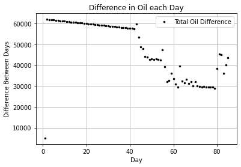

```python
dfTable2 = pd.read_html("<table><tr><th>Day</th><th>Difference Between Days</th></tr><tr><td>1</td><td>5000</td></tr><tr><td>2</td><td>62000</td></tr><tr><td>3</td><td>61888</td></tr><tr><td>4</td><td>61775</td></tr><tr><td>5</td><td>61662</td></tr><tr><td>6</td><td>61550</td></tr><tr><td>7</td><td>61438</td></tr><tr><td>8</td><td>61325</td></tr><tr><td>9</td><td>61212</td></tr><tr><td>10</td><td>61100</td></tr><tr><td>11</td><td>60988</td></tr><tr><td>12</td><td>60875</td></tr><tr><td>13</td><td>60762</td></tr><tr><td>14</td><td>60650</td></tr><tr><td>15</td><td>60538</td></tr><tr><td>16</td><td>60425</td></tr><tr><td>17</td><td>60312</td></tr><tr><td>18</td><td>60200</td></tr><tr><td>19</td><td>60088</td></tr><tr><td>20</td><td>59975</td></tr><tr><td>21</td><td>59862</td></tr><tr><td>22</td><td>59750</td></tr><tr><td>23</td><td>59638</td></tr><tr><td>24</td><td>59525</td></tr><tr><td>25</td><td>59412</td></tr><tr><td>26</td><td>59300</td></tr><tr><td>27</td><td>59188</td></tr><tr><td>28</td><td>59075</td></tr><tr><td>29</td><td>58962</td></tr><tr><td>30</td><td>58850</td></tr><tr><td>31</td><td>58738</td></tr><tr><td>32</td><td>58625</td></tr><tr><td>33</td><td>58512</td></tr><tr><td>34</td><td>58400</td></tr><tr><td>35</td><td>58288</td></tr><tr><td>36</td><td>58175</td></tr><tr><td>37</td><td>58062</td></tr><tr><td>38</td><td>57950</td></tr><tr><td>39</td><td>57838</td></tr><tr><td>40</td><td>57725</td></tr><tr><td>41</td><td>57612</td></tr><tr><td>42</td><td>57500</td></tr><tr><td>43</td><td>59622</td></tr><tr><td>44</td><td>53415</td></tr><tr><td>45</td><td>48818</td></tr><tr><td>46</td><td>48034</td></tr><tr><td>47</td><td>44148</td></tr><tr><td>48</td><td>43822</td></tr><tr><td>49</td><td>42851</td></tr><tr><td>50</td><td>43103</td></tr><tr><td>51</td><td>42788</td></tr><tr><td>52</td><td>43142</td></tr><tr><td>53</td><td>42811</td></tr><tr><td>54</td><td>42437</td></tr><tr><td>55</td><td>47247</td></tr><tr><td>56</td><td>39307</td></tr><tr><td>57</td><td>32076</td></tr><tr><td>58</td><td>32658</td></tr><tr><td>59</td><td>36006</td></tr><tr><td>60</td><td>33595</td></tr><tr><td>61</td><td>30907</td></tr><tr><td>62</td><td>29465</td></tr><tr><td>63</td><td>39533</td></tr><tr><td>64</td><td>32504</td></tr><tr><td>65</td><td>31528</td></tr><tr><td>66</td><td>33157</td></tr><tr><td>67</td><td>31298</td></tr><tr><td>68</td><td>32190</td></tr><tr><td>69</td><td>30206</td></tr><tr><td>70</td><td>32188</td></tr><tr><td>71</td><td>29951</td></tr><tr><td>72</td><td>29651</td></tr><tr><td>73</td><td>29583</td></tr><tr><td>74</td><td>29660</td></tr><tr><td>75</td><td>29475</td></tr><tr><td>76</td><td>29534</td></tr><tr><td>77</td><td>29555</td></tr><tr><td>78</td><td>29572</td></tr><tr><td>79</td><td>29017</td></tr><tr><td>80</td><td>38448</td></tr><tr><td>81</td><td>45251</td></tr><tr><td>82</td><td>45021</td></tr><tr><td>83</td><td>36099</td></tr><tr><td>84</td><td>40158</td></tr><tr><td>85</td><td>43530</td></tr></table>")
df2 = dfTable2[0]

#Graph of data
plt.plot(df2['Day'],df2['Difference Between Days'], "k.", markersize =5, label="Total Oil Difference")
plt.title("Difference in Oil each Day")
plt.xlabel('Day')
plt.ylabel('Difference Between Days')
plt.grid()
plt.legend(loc='best')
print('\033[1m' + 'Figure 5: ' + '\033[0m' + 'Difference in Oil between consecutive days')
```

As **Figure 5** shows along with the curve fitting from **Figure 4.1, 4.2, and 4.3**, a different approach to obtaining the best equation for the data from **Table 1** is necessary. **Figure 5** shows how from Day 1 to about Day 44, there is almost a constant slight decrease in the difference between consecutive points. However, from Day 45 onward, the data becomes a lot less predictable. From Day 45 to around Day 55, we can see that the difference between those ten days are significantly lower, but also closer to each other than from the rest of days. This is also exhibited from Day 56 to Day 79, and again from Day 80 to 85.

As we can see, the overall average change could never speak for the data as a whole because the four subsections of days clearly have varying average changes, from 60k to 45k to 30k and back to 40k. Therefore, we have define a piecewise function for each of these intervals. Since cubic curve fitting seemed to fit the data the best before, we'll use the same fitting on each interval. However, since the average change from [1,44] is fairly constant, linear curve fitting on this interval will prove more than enough.

```
Figure 6.1, 6.2: Piecewise Linear and Cubic Curve Fitting of the Data from Table 1
```

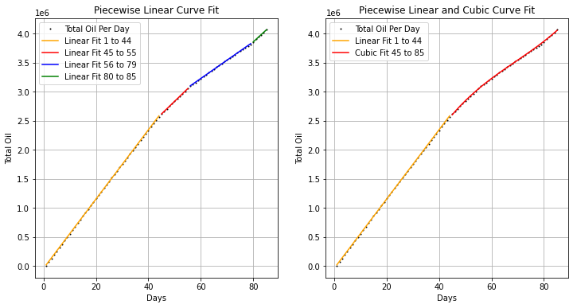

```python
fig, (linear_function, cubic_function) = plt.subplots(nrows = 1, ncols = 2, figsize=(12,6))

#Create the functions for each degree of polynomial
x_1_44 = np.linspace(1,44,440)
x_45_55 = np.linspace(45,55,110)
x_56_79 = np.linspace(56,79,240)
x_80_85 = np.linspace(80,85,60)

linearFormula_1_44 = np.polyfit(df1["Days"][0:44],df1["Total Oil"][0:44],1)
linear_y_1_44 = np.polyval(linearFormula_1_44, x_1_44)

linearFormula_45_55 = np.polyfit(df1["Days"][44:55],df1["Total Oil"][44:55],1)
linear_y_45_55 = np.polyval(linearFormula_45_55, x_45_55)

linearFormula_56_79 = np.polyfit(df1["Days"][55:79],df1["Total Oil"][55:79],1)
linear_y_56_79 = np.polyval(linearFormula_56_79, x_56_79)

linearFormula_80_85 = np.polyfit(df1["Days"][79:],df1["Total Oil"][79:],1)
linear_y_80_85 = np.polyval(linearFormula_80_85, x_80_85)

linear_function.plot(df1["Days"],df1["Total Oil"], "k.", markersize=2)
linear_function.plot(x_1_44, linear_y_1_44, "-", color="orange")
linear_function.plot(x_45_55, linear_y_45_55, "-", color="red")
linear_function.plot(x_56_79, linear_y_56_79, "-", color="blue")
linear_function.plot(x_80_85, linear_y_80_85, "-", color="green")
linear_function.set_title("Piecewise Linear Curve Fit")
linear_function.set_xlabel("Days")
linear_function.set_ylabel("Total Oil")
linear_function.grid()
linear_function.legend(["Total Oil Per Day", "Linear Fit 1 to 44", "Linear Fit 45 to 55", "Linear Fit 56 to 79", "Linear Fit 80 to 85"],loc="best")

cubic_x_45_85 = np.linspace(45,85, 410)
cubicFormula_45_85 = np.polyfit(df1["Days"][44:],df1["Total Oil"][44:],3)
cubic_y_45_85 = np.polyval(cubicFormula_45_85, cubic_x_45_85)

cubic_function.plot(df1["Days"],df1["Total Oil"], "k.", markersize=2)
cubic_function.plot(x_1_44, linear_y_1_44, "-", color="orange")
cubic_function.plot(cubic_x_45_85, cubic_y_45_85, "-", color="red")
cubic_function.set_title("Piecewise Linear and Cubic Curve Fit")
cubic_function.set_xlabel("Days")
cubic_function.set_ylabel("Total Oil")
cubic_function.grid()
cubic_function.legend(["Total Oil Per Day", "Linear Fit 1 to 44", "Cubic Fit 45 to 85"],loc="best")

print('\033[1m' + 'Figure 6.1, 6.2: ' + '\033[0m' + 'Piecewise Linear and Cubic Curve Fitting of the Data from ' + '\033[1m' + 'Table 1' + '\033[0m')
```

```python
print("Linear Formula from Day 1 - 44: y = " + str(linearFormula_1_44[0]) + "x + " + str(linearFormula_1_44[1]))
print("Cubic Formula from Day 45 - 85: y = " + str(cubicFormula_45_85[0]) + "x^3 + " + str(cubicFormula_45_85[1]) + "x^2 + " + str(cubicFormula_45_85[2])
                            + "x + " + str(cubicFormula_45_85[3]))
```

```
Linear Formula from Day 1 - 44: y = 59639.02910500353x + -37726.58668076124
Cubic Formula from Day 45 - 85: y = 12.396183184620797x^3 + -2568.118272658153x^2 + 208080.14221557952x + -2686701.4455350013
```

**Figure 6.1** shows curve fits to each of the intervals determined above to linear lines. While [1,44] is appropriate for a linear curve fit, supported by what we see in **Figure 5**, the rest of the interval is not as appropriate for linear curve fitting. Therefore, we use a cubic curve fit on [45,85]. A quadratic curve fit doesn't fit well on [45,85]. A quintic curve fitting probably would've worked even better than a cubic, but the cubic fits well enough. Thus, we have a piecewise function that is defined as so:

$$ f(x) = \begin{cases} 59639.03x - 37726.59 & 1 \leq x\leq 44 \\ 12.40x^{3} - 2568.12x^{2} + 208080.14x - 2686701.45 & x \geq 45 \end{cases} $$

Using the best model, we can estimate the amount of oil on August 1, 2010. On July 15, 2010, the 85th day, there was about 4 million total barrels of oil leaked. To find the amount of oil on August 1, 2010, we have to use the piecewise function $f(x)$. If July 15 was the 85th day, that means August 1 was the 102nd day and applying that to our equation:

$$ f(102) = \begin{cases} 59639.03x - 37726.59 & 1 \leq x\leq 44 \\ 12.40x^{3} - 2568.12x^{2} + 208080.14x - 2686701.45 & x \geq 45 \end{cases} $$

$$f(102) = 12.40(102)^{3} - 2568.12(102)^{2} + 208080.14(102) - 2686701.45$$$$f(102) = 4977731.55$$

## Derivative of Best Fit Model

Our current model is:

$$ f(x) = \begin{cases} 59639.03x - 37726.59 & 1 \leq x\leq 44 \\ 12.40x^{3} - 2568.12x^{2} + 208080.14x - 2686701.45 & x \geq 45 \end{cases} $$

Because it is a piecewise function, we have to find the derivate on the two different intervals so:

$$ f'(x) = \begin{cases} \frac{d}{dx}(59639.03x - 37726.59) & 1 \leq x\leq 44 \\ \frac{d}{dx}(12.40x^{3} - 2568.12x^{2} + 208080.14x - 2686701.45) & x \geq 45 \end{cases} $$

The derivative of our best fit model is:

$$ f'(x) = \begin{cases} 59639.03 & 1 \leq x\leq 44 \\ 37.2x^{2} - 5136.24x + 208080.14 & x \geq 45 \end{cases} $$

```
Figure 7.1, 7.2: Best Fit Model and its Derivative. The Derivative Model is plotted with the datafrom Table 2
```

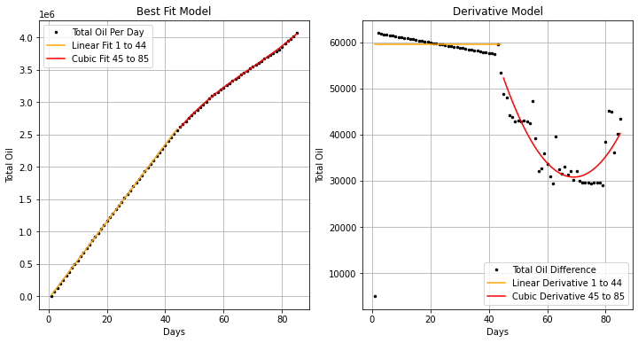

```python
fig, (best_fit_model, derivative_model) = plt.subplots(nrows = 1, ncols = 2, figsize=(12,6))

x_1_44 = np.linspace(1,44,440)
linearFormula_1_44 = np.polyfit(df1["Days"][0:44],df1["Total Oil"][0:44],1)
linear_y_1_44 = np.polyval(linearFormula_1_44, x_1_44)

x_45_85 = np.linspace(45,85, 410)
cubicFormula_45_85 = np.polyfit(df1["Days"][44:],df1["Total Oil"][44:],3)
cubic_y_45_85 = np.polyval(cubicFormula_45_85, x_45_85)

best_fit_model.plot(df1["Days"],df1["Total Oil"], "k.", markersize=5)
best_fit_model.plot(x_1_44, linear_y_1_44, "-", color="orange")
best_fit_model.plot(x_45_85, cubic_y_45_85, "-", color="red")
best_fit_model.set_title("Best Fit Model")
best_fit_model.set_xlabel("Days")
best_fit_model.set_ylabel("Total Oil")
best_fit_model.grid()
best_fit_model.legend(["Total Oil Per Day", "Linear Fit 1 to 44", "Cubic Fit 45 to 85"],loc="best")

derivative_formula_1_44 = 59639.03
def derivative_formula_45_85(x):
    return 37.2*(x**2) - 5136.24*x + 208080.14

derivative_y_1_44 = np.linspace(59639.03,59639.03,440)
derivative_y_45_85 = list(map(derivative_formula_45_85, x_45_85))

derivative_model.plot(df2['Day'],df2['Difference Between Days'], "k.", markersize=5)
derivative_model.plot(x_1_44, derivative_y_1_44, "-", color="orange")
derivative_model.plot(x_45_85, derivative_y_45_85, "-", color="red")
derivative_model.set_title("Derivative Model")
derivative_model.set_xlabel("Days")
derivative_model.set_ylabel("Total Oil")
derivative_model.grid()
derivative_model.legend(["Total Oil Difference","Linear Derivative 1 to 44", "Cubic Derivative 45 to 85"],loc="best")

print('\033[1m' + 'Figure 7.1, 7.2: ' + '\033[0m' + 'Best Fit Model and its Derivative. The Derivative Model is plotted with the data' +
      'from ' + '\033[1m' + 'Table 2' + '\033[0m')
```